# Management Zone Delineation Report

Fuzzy C-Means with PCA dimensionality reduction and ordinary kriging

Author

MZ Analysis

Published

June 19, 2026

# 1 Executive summary

This report summarizes the delineation of **5 management zones** over a study area (Study Area) covering **1,572,337 valid raster cells** (out of 4,089,056 total) at the resolution of the input soil-property raster. Zone counts were evaluated over 2, 3, 4, 5, 6, and the optimal value **k = 5** was selected by the consensus of the Xie-Beni (XB), Fuzzy Performance Index (FPI), and Normalized Classification Entropy (NCE) indices.

The analysis used **99** observation points and **10 soil properties** (BD, CEC, Fragm, Sand, Silt, Clay, N, OCD, pH, SOC). Membership surfaces were interpolated by **kriging**; 88.3% of the study area falls in a transition zone (maximum membership below 0.6).

# 2 1. Inputs

The pipeline reads three local data sources. Their metadata is summarized below.

Input data summary

| Input | File | Format | Description |
| --- | --- | --- | --- |
| Study-area boundary | agro_geo.gpkg | GeoPackage, 1 feature(s) | Single polygon defining the crop field extent |
| Soil-property raster | soil_predictions.tif | GeoTIFF, 10 layer(s), 4,090,752 cells | Multi-layer stack: BD, CEC, Fragm, Sand, Silt, Clay, N, OCD, pH, SOC |
| Observation points | soilgrids_data.csv | CSV, 99 rows, 13 cols | Columns: fid, longitude, latitude, BD, CEC, Fragm, Sand, Silt, Clay, N, OCD, pH, SOC |

## 2.2 1.2 Study-area boundary

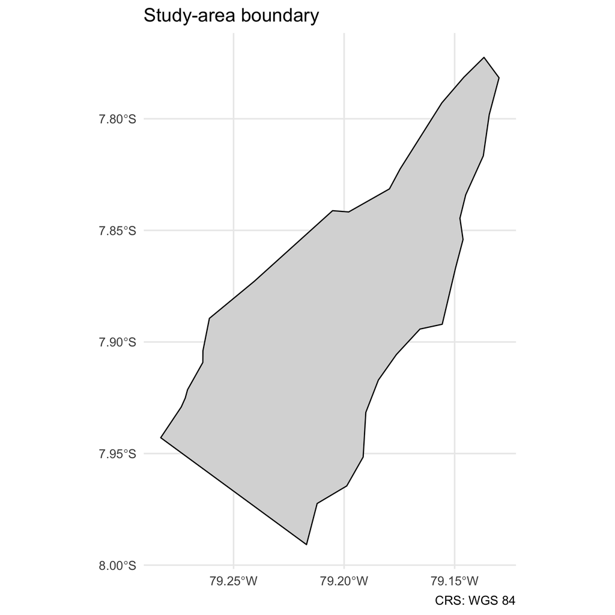

Study-area boundary

# 3 2. Pre-processing

## 3.1 2.1 Raster value extraction at observation points

Raster values were extracted at every observation point using `terra::extract` (called with the `terra::` namespace to avoid a collision with `tidyr::extract`). Where the raster layer name matched a column in the input CSV, the raster value overwrote the CSV value; otherwise the CSV value was retained.

## 3.2 2.2 NA imputation and normalization

Any remaining missing values in the soil-property matrix were median-imputed per variable. Features were then min-max normalized to the unit interval `[0, 1]` to make them commensurate for the PCA and FCM stages.

# 4 3. Dimensionality reduction (PCA)

PCA was run on the normalized feature matrix (no centering or scaling, since inputs are already in `[0, 1]`). Principal components were retained until cumulative variance reached 80%.

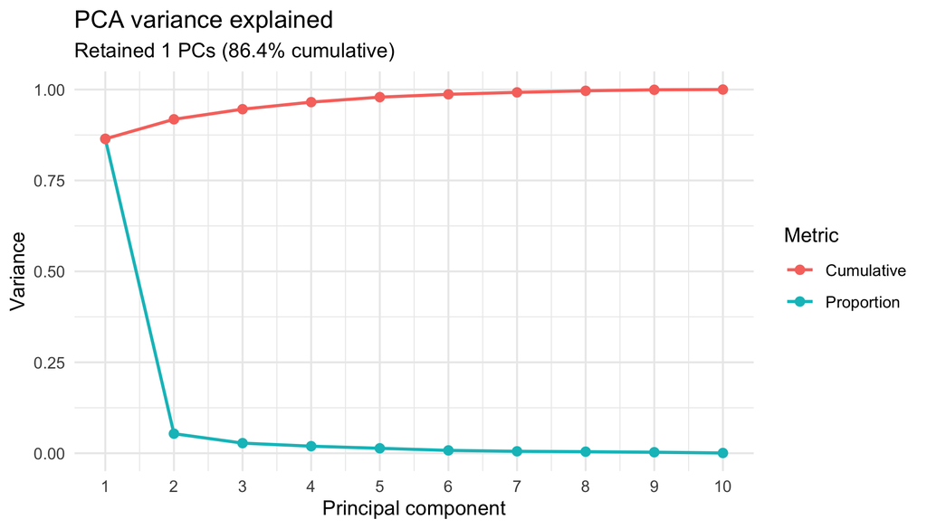

PCA scree plot (cumulative variance)

PCA eigenvalues and variance explained

| PC | Eigenvalue | Proportion | Cumulative |
| --- | --- | --- | --- |
| 1 | 2.4066 | 0.8644 | 0.8644 |
| 2 | 0.1498 | 0.0538 | 0.9182 |
| 3 | 0.0775 | 0.0278 | 0.9460 |
| 4 | 0.0541 | 0.0194 | 0.9654 |
| 5 | 0.0379 | 0.0136 | 0.9791 |
| 6 | 0.0218 | 0.0078 | 0.9869 |
| 7 | 0.0148 | 0.0053 | 0.9922 |
| 8 | 0.0121 | 0.0043 | 0.9965 |
| 9 | 0.0077 | 0.0028 | 0.9993 |
| 10 | 0.0020 | 0.0007 | 1.0000 |

# 5 4. Cluster-validity analysis

Fuzzy C-Means was fit on the retained PCA scores for every `k` in 2, 3, 4, 5, 6 (fuzziness m = 2, `iter.max = 300`, fixed seed = 42). Five cluster-validity indices were computed:

- **XB** — Xie-Beni index (lower is better)
- **FPI** — Fuzzy Performance Index (lower is better; McBratney & Moore 1985)
- **NCE** — Normalized Classification Entropy (lower is better)
- **PE** — Partition Entropy (lower is better)
- **FS** — Fukuyama-Sugeno index (lower is better)

The optimal `k` was selected as the **consensus minimum** of the XB, FPI, and NCE ranks.

Cluster-validity indices and ranks

| k | XB | FPI | NCE | PE | FS | XB_rank | FPI_rank | NCE_rank | consensus_rank |
| --- | --- | --- | --- | --- | --- | --- | --- | --- | --- |
| 5 | 0.06231 | 0.2695 | 0.2716 | 0.4372 | -107.40 | 1 | 2 | 2 | 5 |
| 6 | 0.11020 | 0.2621 | 0.2523 | 0.4521 | -125.10 | 5 | 1 | 1 | 7 |
| 3 | 0.09171 | 0.2948 | 0.3286 | 0.3610 | -82.69 | 2 | 3 | 4 | 9 |
| 4 | 0.09621 | 0.3000 | 0.3086 | 0.4278 | -97.85 | 3 | 4 | 3 | 10 |
| 2 | 0.10400 | 0.3751 | 0.4379 | 0.3035 | -46.34 | 4 | 5 | 5 | 14 |

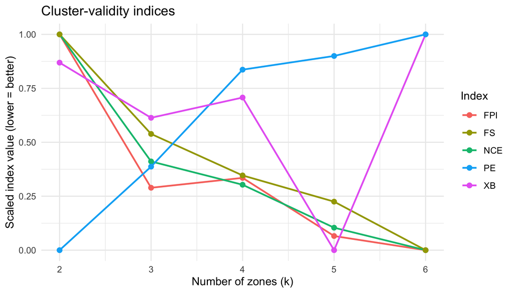

Cluster-validity indices (min-max scaled, lower = better)

# 6 5. Final FCM model and zone map

The final FCM was fit with the optimal k = 5 (consensus rank = 5). Each observation point was assigned to the zone with the largest membership, and the `k` membership surfaces were interpolated across the study area by kriging.

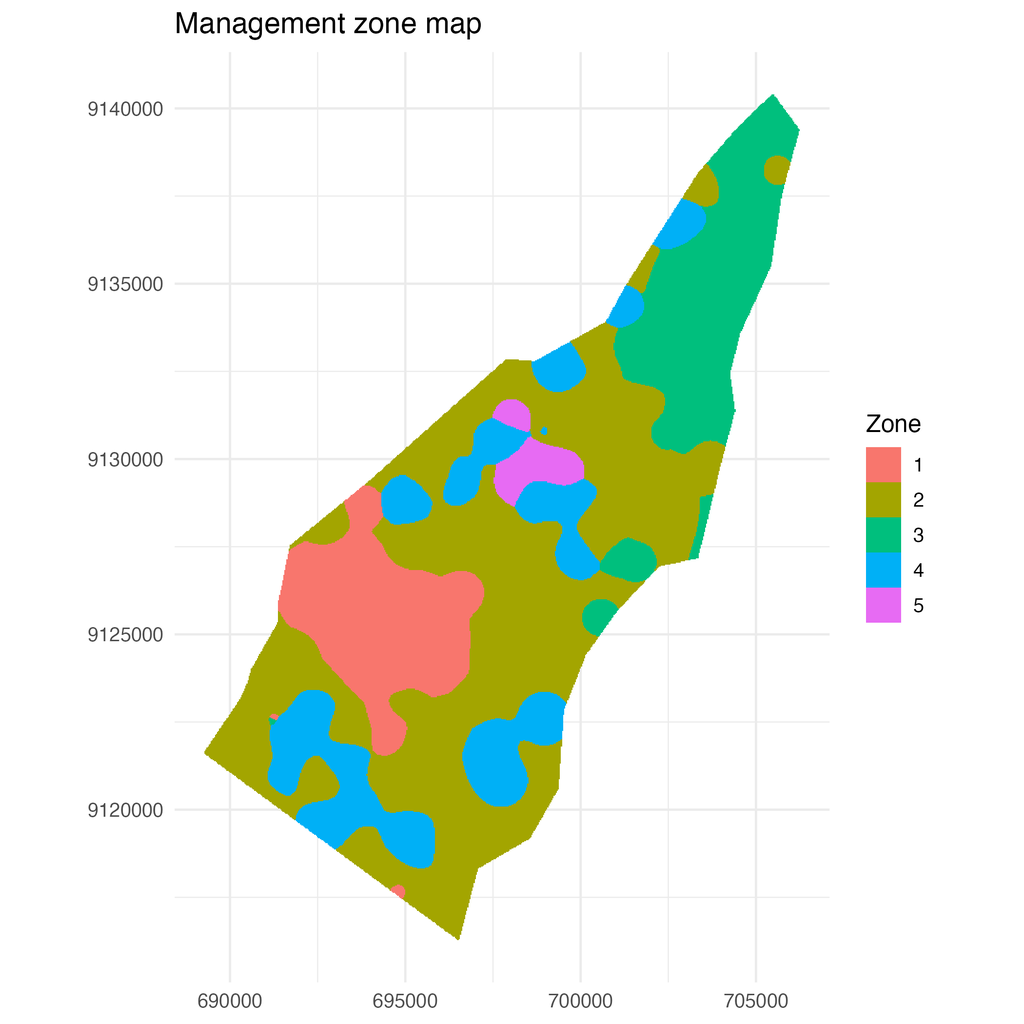

Management zone map (k = optimal)

## 6.1 5.1 Zone assignment summary

Observation points per zone

| Zone | Points | Share (%) |
| --- | --- | --- |
| 1 | 12 | 12.1 |
| 2 | 37 | 37.4 |
| 3 | 21 | 21.2 |
| 4 | 25 | 25.3 |
| 5 | 4 | 4.0 |

## 6.2 5.2 Transition mask

A cell is flagged as a transition zone when the maximum membership at that cell is below 0.6. **88.3%** of the study area falls in this category; the remaining 11.7% is a “core” zone with a confident assignment.

# 7 6. Zone statistics

| Zone | BD | CEC | Fragm | Sand | Silt | Clay | N | OCD | pH | SOC |
| --- | --- | --- | --- | --- | --- | --- | --- | --- | --- | --- |
| 1 | 1.37 | 13.4 | 15.4 | 78.6 | 12.9 | 8.50 | 3.19 | 14.3 | 7.48 | 13.9 |
| 2 | 1.37 | 13.8 | 16.9 | 78.8 | 12.7 | 8.42 | 3.09 | 14.2 | 7.68 | 14.0 |
| 3 | 1.38 | 14.3 | 15.7 | 77.4 | 13.6 | 9.01 | 2.42 | 13.3 | 7.66 | 12.5 |
| 4 | 1.38 | 13.8 | 17.4 | 78.6 | 12.9 | 8.47 | 3.43 | 14.3 | 7.71 | 14.6 |
| 5 | 1.38 | 14.0 | 17.8 | 79.3 | 12.6 | 8.10 | 4.39 | 15.8 | 7.69 | 13.6 |

## 7.1 6.1 ANOVA and effect size (η²)

For each soil variable, a one-way ANOVA tested the null hypothesis that the variable mean is equal across zones. The η² effect size is reported in addition to the p-value.

Per-variable ANOVA and effect size

| Variable | η² | p-value | Sig. |
| --- | --- | --- | --- |
| BD | 0.068 | 0.1504000 |  |
| CEC | 0.084 | 0.0817400 | . |
| Fragm | 0.351 | 0.0000000 | *** |
| Sand | 0.117 | 0.0191300 | * |
| Silt | 0.089 | 0.0649000 | . |
| Clay | 0.067 | 0.1580000 |  |
| N | 0.269 | 0.0000054 | *** |
| OCD | 0.147 | 0.0044040 | ** |
| pH | 0.237 | 0.0000360 | *** |
| SOC | 0.047 | 0.3339000 |  |

> **Note.** The η² values above are computed on the original CSV observations for transparency. The per-zone means in the previous table were computed on the post-extraction matrix (raster values overwrite CSV values where available) used during clustering. Differences are small in practice and only affect cells where the CSV had a value and the raster had a different one.

# 8 7. Uncertainty map (membership entropy)

Fuzzy assignments carry intrinsic uncertainty: a cell near the boundary between two zones will have intermediate memberships for both. The Shannon entropy of the membership vector at each cell summarizes this:

$$H(\mathbf{u}) = -\sum_{j=1}^{k} u_j \log u_j$$

Higher entropy ⇒ more ambiguous assignment. This is a useful diagnostic, since transition zones defined by a hard threshold (Section 5.2) lose the gradient information.

Entropy distribution

[output not shown]

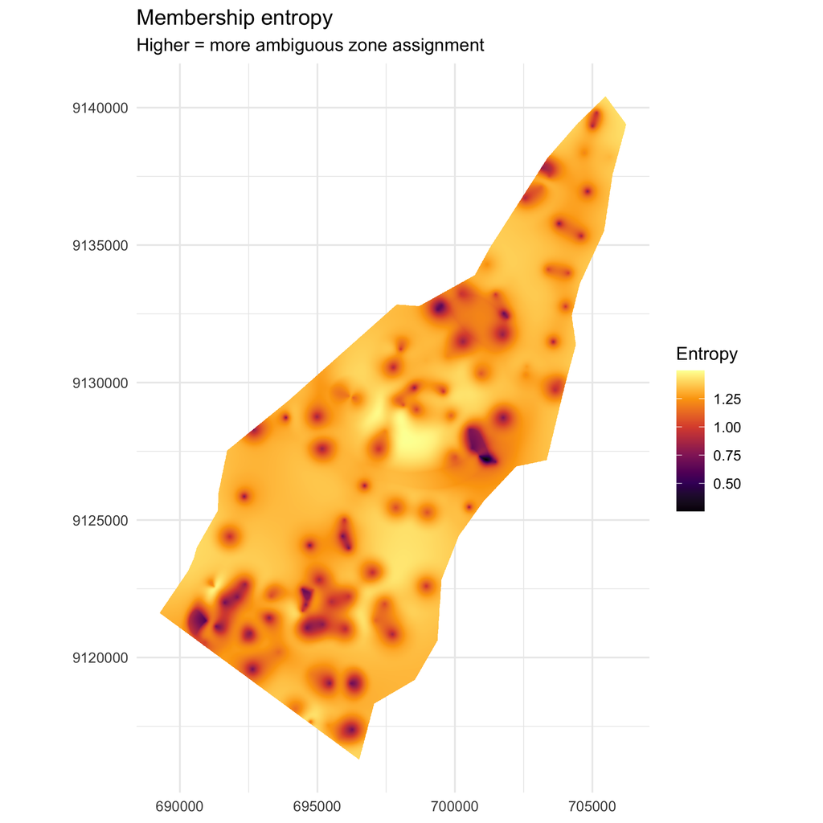

# 9 8. Reproducibility

**Pipeline parameters**

| Parameter | Value |
| --- | --- |
| Fuzziness (m) | 2 |
| k range | 2, 3, 4, 5, 6 |
| PCA cumulative-variance threshold | 0.8 |
| Transition threshold (max membership) | 0.6 |
| Interpolation method | kriging |
| Random seed | 42 |

**R session info**

``` R version 4.6.0 (2026-04-24) Platform: aarch64-apple-darwin23 Running under: macOS Tahoe 26.5.1 Matrix products: default BLAS: /Library/Frameworks/R.framework/Versions/4.6/Resources/lib/libRblas.0.dylib LAPACK: /Library/Frameworks/R.framework/Versions/4.6/Resources/lib/libRlapack.dylib; LAPACK version 3.12.1 locale: [1] C.UTF-8/C.UTF-8/C.UTF-8/C/C.UTF-8/C.UTF-8 time zone: America/Lima tzcode source: internal attached base packages: [1] stats graphics grDevices utils datasets methods base other attached packages: [1] effectsize_1.0.2 knitr_1.51 tidyr_1.3.2 dplyr_1.2.1 [5] ggplot2_4.0.3 sf_1.1-1 terra_1.9-27 loaded via a namespace (and not attached): [1] s2_1.1.11 generics_0.1.4 class_7.3-23 KernSmooth_2.23-26 [5] digest_0.6.39 magrittr_2.0.5 evaluate_1.0.5 grid_4.6.0 [9] RColorBrewer_1.1-3 fastmap_1.2.0 jsonlite_2.0.0 e1071_1.7-17 [13] DBI_1.3.0 purrr_1.2.2 viridisLite_0.4.3 scales_1.4.0 [17] codetools_0.2-20 cli_3.6.6 rlang_1.2.0 units_1.0-1 [21] withr_3.0.2 yaml_2.3.12 otel_0.2.0 datawizard_1.3.1 [25] tools_4.6.0 bayestestR_0.18.1 vctrs_0.7.3 R6_2.6.1 [29] png_0.1-9 proxy_0.4-29 lifecycle_1.0.5 classInt_0.4-11 [33] htmlwidgets_1.6.4 insight_1.5.1 pkgconfig_2.0.3 pillar_1.11.1 [37] gtable_0.3.6 glue_1.8.1 Rcpp_1.1.1-1.1 xfun_0.58 [41] tibble_3.3.1 tidyselect_1.2.1 parameters_0.29.1 farver_2.1.2 [45] htmltools_0.5.9 rmarkdown_2.31 labeling_0.4.3 wk_0.9.5 [49] compiler_4.6.0 S7_0.2.2 ```

*Report generated by `report/mz_report.qmd` on 2026-06-19 22:23:55 -05.*